# NYPD Shooting Incident Data Report

05 December 2022

## Introduction

This project illustrates the steps in the data science process in a reproducible way. I am creating a report on the NYPD Shooting incident data from 2006 to 2021. You will see that the steps in the data science process have been followed.

- Import data
- Tidy
- Analyze

This project also contains at least two visualizations, incorporates population data for comparison among boroughs, and integrates employment data for the modeling. Finally, some potential bias is identified.

### Sources

- https://catalog.data.gov/
- https://data.cityofnewyork.us/
- https://scholar.harvard.edu/files/angelalee/files/1-s2.0-s0049089x19301188-main.pdf
  - “A time-sensitive analysis of the work-crime relationship for young men” by Angela Wang Lee, Department of Sociology, Harvard University

## About the data

For this project, we are interested in the following variables:

- OCCUR_DATE: Date
- BORO: Borough
- STATISTICAL_MURDER_FLAG: Murder
- PERP_AGE_GROUP: Perpetrator’s Age
- PERP_SEX: Perpetrator’s Sex
- PERP_RACE: Perpetrator’s Race
- VIC_AGE_GROUP: Victim’s Age
- VIC_SEX: Victim’s Sex
- VIC_RACE: Victim’s Race

We also introduce: **Population per Borough** and **Employment per Borough**

## Import data

```r
library(readr)

nypd_shooting_url_in <- "https://data.cityofnewyork.us/api/views/833y-fsy8/rows.csv?accessType=DOWNLOAD"
nypd_shooting_incident_data <- read_csv(nypd_shooting_url_in)
```

## Tidy

```r
library(dplyr)
library(lubridate)

# Removing unnecessary columns, date formatting, and renaming

nypd_shooting_incident_data <- nypd_shooting_incident_data %>%
    select(-c(INCIDENT_KEY,
        X_COORD_CD,
        Y_COORD_CD,
        Latitude,
        Longitude,
        Lon_Lat,
        PRECINCT,
        JURISDICTION_CODE,
        LOCATION_DESC,
        OCCUR_TIME)) %>%
    mutate(OCCUR_DATE = mdy(OCCUR_DATE)) %>%
    rename(occur_date = `OCCUR_DATE`,
        boro = `BORO`,
        murder = `STATISTICAL_MURDER_FLAG`,
        perp_age = `PERP_AGE_GROUP`,
        perp_sex = `PERP_SEX`,
        perp_race = `PERP_RACE`,
        vic_age = `VIC_AGE_GROUP`,
        vic_sex = `VIC_SEX`,
        vic_race = `VIC_RACE`)

summary(nypd_shooting_incident_data)
```

```
##    occur_date             boro             murder          perp_age
##  Min.   :2006-01-01   Length:25596       Mode :logical   Length:25596
##  1st Qu.:2009-05-10   Class :character   FALSE:20668     Class :character
##  Median :2012-08-26   Mode  :character   TRUE :4928      Mode  :character
##  Mean   :2013-06-13
##  3rd Qu.:2017-07-01
##  Max.   :2021-12-31
##    perp_sex          perp_race           vic_age            vic_sex
##  Length:25596       Length:25596       Length:25596       Length:25596
##  Class :character   Class :character   Class :character   Class :character
##  Mode  :character   Mode  :character   Mode  :character   Mode  :character
##
##
##
##    vic_race
##  Length:25596
##  Class :character
##  Mode  :character
##
##
##
```

## Transform

```r
library(tidyr)
library(stringr)
library(ggplot2)

# Incorporating population by borough, removing unnecessary columns, date formatting, data mutation

nyc_population_url_in <- "https://data.cityofnewyork.us/resource/xywu-7bv9.csv"
nyc_population <- read_csv(nyc_population_url_in)
nyc_population <- nyc_population %>%
    select(-c(age_group, contains("_boro"))) %>%
    pivot_longer(cols = -`borough`, names_to = "pop_year", values_to = "population") %>%
    mutate(pop_year = str_sub(pop_year, 2, 5), borough = str_to_upper(borough)) %>%
    mutate(pop_year = ymd(pop_year, truncated = 2L)) %>%
    rename(boro = `borough`)

nypd_shooting_incident_data <- nypd_shooting_incident_data %>%
    left_join(nyc_population, by = "boro") %>%
    filter(year(occur_date) %% year(pop_year) <= 9)

summary(nypd_shooting_incident_data)
```

```
##    occur_date             boro             murder          perp_age
##  Min.   :2006-01-01   Length:25596       Mode :logical   Length:25596
##  1st Qu.:2009-05-10   Class :character   FALSE:20668     Class :character
##  Median :2012-08-26   Mode  :character   TRUE :4928      Mode  :character
##  Mean   :2013-06-13
##  3rd Qu.:2017-07-01
##  Max.   :2021-12-31
##    perp_sex          perp_race           vic_age            vic_sex
##  Length:25596       Length:25596       Length:25596       Length:25596
##  Class :character   Class :character   Class :character   Class :character
##  Mode  :character   Mode  :character   Mode  :character   Mode  :character
##
##
##
##    vic_race            pop_year            population
##  Length:25596       Min.   :2000-01-01   Min.   : 443728
##  Class :character   1st Qu.:2000-01-01   1st Qu.:1385108
##  Mode  :character   Median :2010-01-01   Median :2250002
##                     Mean   :2008-07-11   Mean   :1979652
##                     3rd Qu.:2010-01-01   3rd Qu.:2552911
##                     Max.   :2020-01-01   Max.   :2648452
```

## Visualize

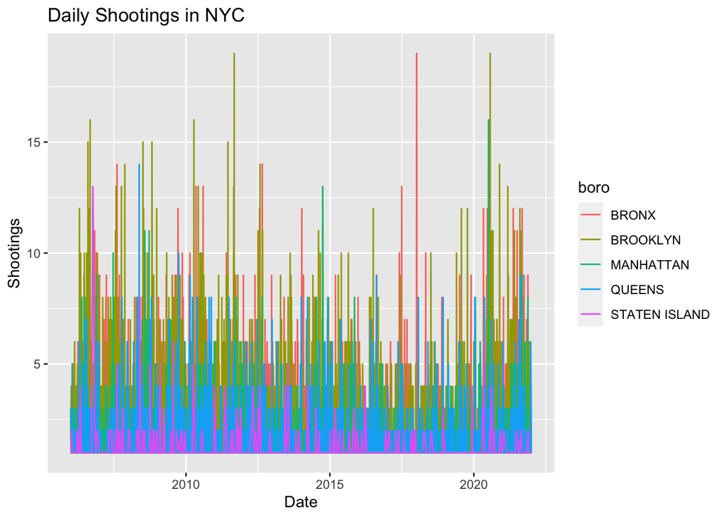

```r
# Plot shootings per day per borough

nypd_shooting_incident_data %>%
    mutate(shootings = 1) %>%
    group_by(occur_date, boro) %>%
    summarise(shootings = sum(shootings)) %>%
    ggplot(aes(x = occur_date, y = shootings, color = boro)) +
    geom_line() +
    labs(
        title = "Daily Shootings in NYC",
        x = "Date",
        y = "Shootings")
```

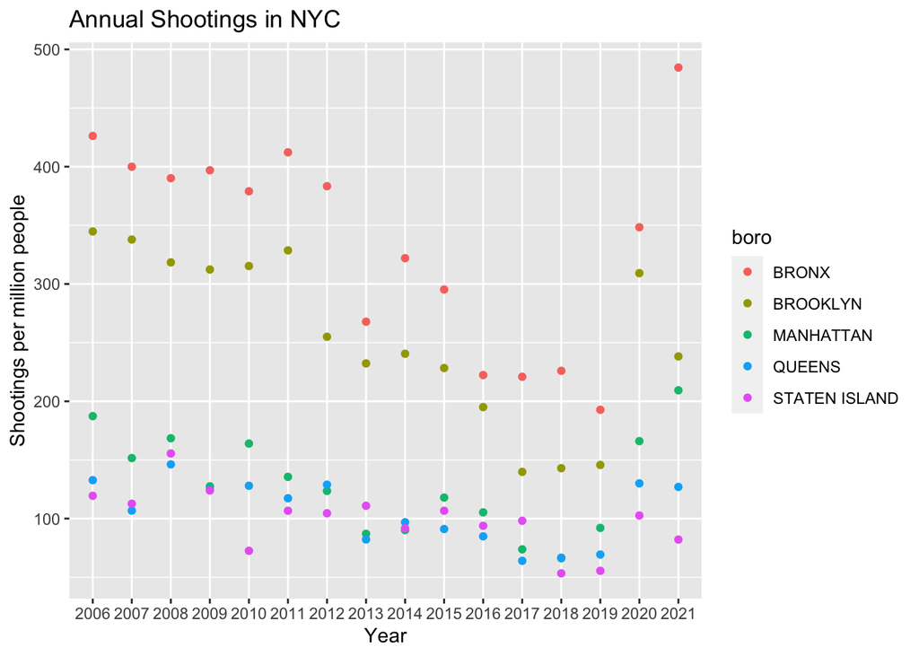

```r
# Plot shootings per year per borough per million population

nypd_shooting_incident_data %>%
    mutate(shootings = 1, occur_year = str_sub(occur_date, 1, 4)) %>%
    group_by(occur_year, boro, population) %>%
    summarise(shootings = sum(shootings)) %>%
    mutate(shootings_per_mill = shootings * 1000000 / population) %>%
    ggplot(aes(x = occur_year, y = shootings_per_mill, color = boro)) +
    geom_point() +
    labs(
        title = "Annual Shootings in NYC",
        x = "Year",
        y = "Shootings per million people")
```

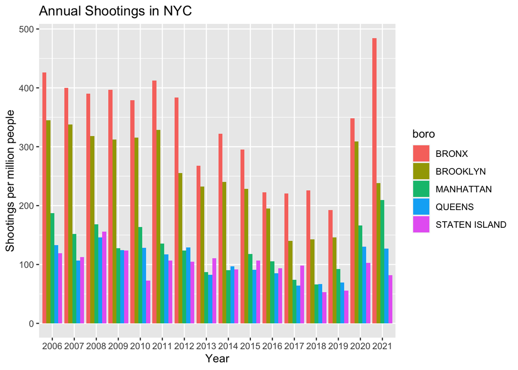

```r
nypd_shooting_incident_data %>%
    mutate(shootings = 1, occur_year = str_sub(occur_date, 1, 4)) %>%
    group_by(occur_year, boro, population) %>%
    summarise(shootings = sum(shootings)) %>%
    mutate(shootings_per_mill = shootings * 1000000 / population) %>%
    ggplot(aes(x = occur_year, y = shootings_per_mill, fill = boro)) +
    geom_bar(stat = "identity", position = position_dodge()) +
    labs(
        title = "Annual Shootings in NYC",
        x = "Year",
        y = "Shootings per million people")
```

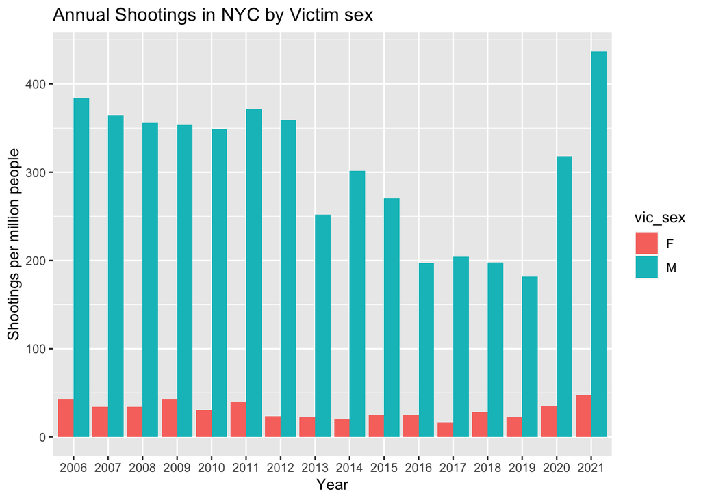

```r
# Plot shooting victims by sex

vic_by_sex <- nypd_shooting_incident_data %>%
    mutate(shootings = 1, occur_year = str_sub(occur_date, 1, 4)) %>%
    group_by(occur_year, boro, population, vic_sex) %>%
    summarise(shootings = sum(shootings)) %>%
    mutate(shootings_per_mill = shootings * 1000000 / population)

vic_by_sex %>%
    filter(vic_sex != "U") %>%
    group_by(occur_year, vic_sex, population) %>%
    summarise(shootings = sum(shootings)) %>%
    mutate(shootings_per_mill = shootings * 1000000 / population) %>%
    ggplot(aes(x = occur_year, y = shootings_per_mill, fill = vic_sex)) +
    geom_bar(stat = "identity", position = position_dodge()) +
    labs(
        title = "Annual Shootings in NYC by Victim sex",
        x = "Year",
        y = "Shootings per million people")
```

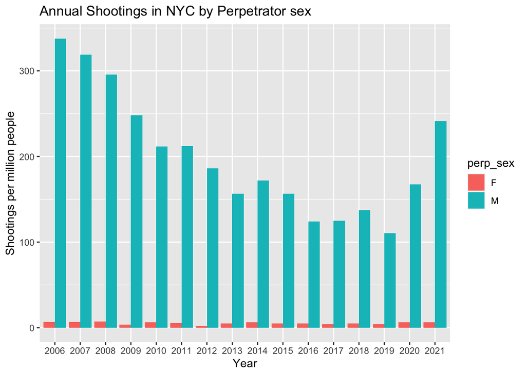

```r
# Plot shooting perpetrators by sex

perp_by_sex <- nypd_shooting_incident_data %>%
    mutate(shootings = 1, occur_year = str_sub(occur_date, 1, 4)) %>%
    group_by(occur_year, boro, population, perp_sex) %>%
    summarise(shootings = sum(shootings)) %>%
    mutate(shootings_per_mill = shootings * 1000000 / population)

perp_by_sex %>%
    drop_na() %>%
    filter(perp_sex != "U") %>%
    group_by(occur_year, perp_sex, population) %>%
    summarise(shootings = sum(shootings)) %>%
    mutate(shootings_per_mill = shootings * 1000000 / population) %>%
    ggplot(aes(x = occur_year, y = shootings_per_mill, fill = perp_sex)) +
    geom_bar(stat = "identity", position = position_dodge()) +
        labs(
        title = "Annual Shootings in NYC by Perpetrator sex",
        x = "Year",
        y = "Shootings per million people")
```

## Modeling Data

```r
nypd_shooting_month <- nypd_shooting_incident_data %>%
    mutate(shootings = 1) %>%
    group_by(date = floor_date(occur_date, "month")) %>%
    summarise(shootings = sum(shootings))

# Introducing Employment in NYC

employment <- read_csv("https://data.cityofnewyork.us/api/views/5hjv-bjbv/rows.csv?accessType=DOWNLOAD")
tot_employ <- employment %>%
    filter(INDUSTRY == "Total Private") %>%
    select(-c(`PUBLICATION DATE`,
        INDUSTRY,
        METHOD,
        `REVISION REASON`)) %>%
    rename(year = `REFERENCE YEAR`,
        month = `REFERENCE MONTH`,
        employment = `EMPLOYMENT`)

tot_employ_month <- tot_employ %>%
        mutate(date = str_c(year, "-", month)) %>%
        mutate(date = ym(date)) %>%
        select(-c(year, month))

shooting_employment <- nypd_shooting_month %>%
    left_join(tot_employ_month, by = "date") %>%
     group_by(date) %>%
     summarise(shootings = max(shootings), employment = max(employment))

# Model

mod <- lm(shootings ~ employment, data = shooting_employment)
summary(mod)
```

```
##
## Call:
## lm(formula = shootings ~ employment, data = shooting_employment)
##
## Residuals:
##    Min     1Q Median     3Q    Max
## -91.17 -31.53  -4.14  24.91 183.70
##
## Coefficients:
##              Estimate Std. Error t value Pr(>|t|)
## (Intercept) 443.40650   36.72862  12.073  < 2e-16 ***
## employment   -0.08818    0.01040  -8.477 6.35e-15 ***
## ---
## Signif. codes:  0 '***' 0.001 '**' 0.01 '*' 0.05 '.' 0.1 ' ' 1
##
## Residual standard error: 45.44 on 190 degrees of freedom
## Multiple R-squared:  0.2744, Adjusted R-squared:  0.2706
## F-statistic: 71.85 on 1 and 190 DF,  p-value: 6.352e-15
```

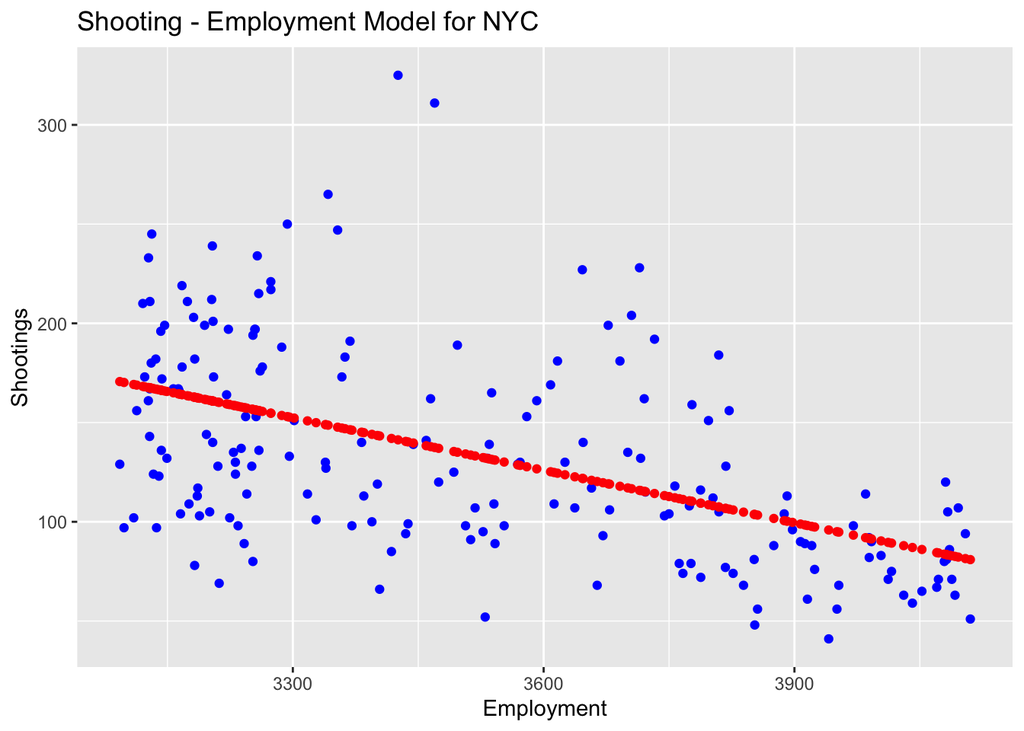

```r
shooting_employment_w_pred <- shooting_employment %>%
    mutate(pred = predict(mod))

shooting_employment_w_pred %>%
    ggplot() +
    geom_point(aes(x = employment, y = shootings), color = "blue") +
    geom_point(aes(x = employment, y = pred), color = "red") +
        labs(
        title = "Shooting - Employment Model for NYC",
        x = "Employment",
        y = "Shootings")
```

## Possible Bias

In this report, some bias could have been introduced in a few parts, such as when the population is incorporated and how NA and undefined values are handled. Population data comes from https://data.cityofnewyourk.us, and we assume that it is accurate; also, for simplicity, I ignore NA and undefined values, but in a different context, these values would deserve some more analysis. As for personal bias, I had the pre-conception that some boroughs would have more shootings than others and that men are more prone to commit shootings while women tend to be the victims. I expected, for example, that Manhattan would have the least number of shootings when adjusting by population, but that was not the case. In the same way, I expected more female victims, but that wasn’t the case, either.

## Analysis

This analysis comes in three tiers. First, shootings by borough; second, sex dynamics; and third, employment in correlation to shootings. Contrary to my expectations, I found that Manhattan has plenty of shootings; most of the time, Manhattan’s shootings come third, just below Bronx and Brooklyn. Queens and Staten Island are at the bottom, with around 100 annual shootings per million people, while the Bronx has the most shootings at about 5 times Staten Island’s figures. Shootings are mostly a male phenomenon in NYC, as men are protagonists in most of the incidents. This begs the question of what other factors are causing these shootings in NYC. Some Theories suggest that there is a relationship between work and crime, so I introduced “Total Private” employment as a proxy to work and created a linear model to explain shootings (crime) in relation to employment (work). There seems to be an inverse relationship between shootings and employment which concurs with the literature.

## Conclusion

As we understand crime and shootings, we observe that employment catalyzes prosperity and peace in society. Also, the data strongly suggest paying particular attention to male actors as they are involved in most shootings.